# Optimal Treatment Analysis

## Outcome Variable

**Outcome Variable:** haz

## Predictor Variables

**Intervention Variable:** predexfd6

**Adjustment Set:**

- arm
- sex
- brthmon
- W_mage
- meducyrs
- feducyrs
- hhwealth_quart
- hfoodsec
- W_mhtcm
- W_mwtkg
- W_mbmi
- vagbrth
- W_gagebrth
- W_birthwt
- W_birthlen
- W_nrooms
- W_nchldlt5
- month
- W_parity
- impfloor
- impsan
- safeh20
- delta_W_mage
- delta_meducyrs
- delta_feducyrs
- delta_hhwealth_quart
- delta_hfoodsec
- delta_W_mhtcm
- delta_W_mwtkg
- delta_W_mbmi
- delta_vagbrth
- delta_W_gagebrth
- delta_W_birthwt
- delta_W_birthlen
- delta_W_nrooms
- delta_W_nchldlt5
- delta_month
- delta_W_parity
- delta_impfloor
- delta_impsan
- delta_safeh20

## Stratifying Variables

The analysis was stratified on these variable(s):

- agecat
- studyid
- country

## Data Summary

| agecat | studyid | country | predexfd6 | n_cell | n |
| --- | --- | --- | --- | --- | --- |
| Birth | ki0047075b-MAL-ED | BANGLADESH | 1 | 72 | 205 |
| Birth | ki0047075b-MAL-ED | BANGLADESH | 0 | 133 | 205 |
| Birth | ki0047075b-MAL-ED | BRAZIL | 1 | 6 | 60 |
| Birth | ki0047075b-MAL-ED | BRAZIL | 0 | 54 | 60 |
| Birth | ki0047075b-MAL-ED | INDIA | 1 | 4 | 39 |
| Birth | ki0047075b-MAL-ED | INDIA | 0 | 35 | 39 |
| Birth | ki0047075b-MAL-ED | NEPAL | 1 | 3 | 24 |
| Birth | ki0047075b-MAL-ED | NEPAL | 0 | 21 | 24 |
| Birth | ki0047075b-MAL-ED | PERU | 1 | 73 | 213 |
| Birth | ki0047075b-MAL-ED | PERU | 0 | 140 | 213 |
| Birth | ki0047075b-MAL-ED | SOUTH AFRICA | 1 | 1 | 91 |
| Birth | ki0047075b-MAL-ED | SOUTH AFRICA | 0 | 90 | 91 |
| Birth | ki0047075b-MAL-ED | TANZANIA, UNITED REPUBLIC OF | 1 | 0 | 113 |
| Birth | ki0047075b-MAL-ED | TANZANIA, UNITED REPUBLIC OF | 0 | 113 | 113 |
| Birth | ki1000108-CMC-V-BCS-2002 | INDIA | 1 | 7 | 7 |
| Birth | ki1000108-CMC-V-BCS-2002 | INDIA | 0 | 0 | 7 |
| Birth | ki1000108-IRC | INDIA | 1 | 0 | 14 |
| Birth | ki1000108-IRC | INDIA | 0 | 14 | 14 |
| Birth | ki1000109-EE | PAKISTAN | 1 | 38 | 42 |
| Birth | ki1000109-EE | PAKISTAN | 0 | 4 | 42 |
| Birth | ki1000304b-SAS-CompFeed | INDIA | 1 | 346 | 364 |
| Birth | ki1000304b-SAS-CompFeed | INDIA | 0 | 18 | 364 |
| Birth | ki1017093b-PROVIDE | BANGLADESH | 1 | 159 | 539 |
| Birth | ki1017093b-PROVIDE | BANGLADESH | 0 | 380 | 539 |
| Birth | ki1101329-Keneba | GAMBIA | 1 | 485 | 1403 |
| Birth | ki1101329-Keneba | GAMBIA | 0 | 918 | 1403 |
| Birth | ki1113344-GMS-Nepal | NEPAL | 1 | 419 | 563 |
| Birth | ki1113344-GMS-Nepal | NEPAL | 0 | 144 | 563 |
| Birth | kiGH5241-JiVitA-3 | BANGLADESH | 1 | 10466 | 13423 |
| Birth | kiGH5241-JiVitA-3 | BANGLADESH | 0 | 2957 | 13423 |

[output cut: 70 more lines]

The following strata were considered:

- agecat: 24 months, studyid: ki0047075b-MAL-ED, country: BANGLADESH
- agecat: 24 months, studyid: ki0047075b-MAL-ED, country: BRAZIL
- agecat: 24 months, studyid: ki0047075b-MAL-ED, country: INDIA
- agecat: 24 months, studyid: ki0047075b-MAL-ED, country: NEPAL
- agecat: 24 months, studyid: ki0047075b-MAL-ED, country: PERU
- agecat: 24 months, studyid: ki0047075b-MAL-ED, country: SOUTH AFRICA
- agecat: 24 months, studyid: ki0047075b-MAL-ED, country: TANZANIA, UNITED REPUBLIC OF
- agecat: 24 months, studyid: ki1000108-CMC-V-BCS-2002, country: INDIA
- agecat: 24 months, studyid: ki1000108-IRC, country: INDIA
- agecat: 24 months, studyid: ki1000109-EE, country: PAKISTAN
- agecat: 24 months, studyid: ki1017093b-PROVIDE, country: BANGLADESH
- agecat: 24 months, studyid: ki1101329-Keneba, country: GAMBIA
- agecat: 24 months, studyid: ki1113344-GMS-Nepal, country: NEPAL
- agecat: 24 months, studyid: ki1148112-LCNI-5, country: MALAWI
- agecat: 24 months, studyid: kiGH5241-JiVitA-3, country: BANGLADESH
- agecat: 24 months, studyid: kiGH5241-JiVitA-4, country: BANGLADESH
- agecat: 6 months, studyid: ki0047075b-MAL-ED, country: BANGLADESH
- agecat: 6 months, studyid: ki0047075b-MAL-ED, country: BRAZIL
- agecat: 6 months, studyid: ki0047075b-MAL-ED, country: INDIA
- agecat: 6 months, studyid: ki0047075b-MAL-ED, country: NEPAL
- agecat: 6 months, studyid: ki0047075b-MAL-ED, country: PERU
- agecat: 6 months, studyid: ki0047075b-MAL-ED, country: SOUTH AFRICA
- agecat: 6 months, studyid: ki0047075b-MAL-ED, country: TANZANIA, UNITED REPUBLIC OF
- agecat: 6 months, studyid: ki1000108-CMC-V-BCS-2002, country: INDIA
- agecat: 6 months, studyid: ki1000108-IRC, country: INDIA
- agecat: 6 months, studyid: ki1000109-EE, country: PAKISTAN
- agecat: 6 months, studyid: ki1000304b-SAS-CompFeed, country: INDIA
- agecat: 6 months, studyid: ki1000304b-SAS-FoodSuppl, country: INDIA
- agecat: 6 months, studyid: ki1017093b-PROVIDE, country: BANGLADESH
- agecat: 6 months, studyid: ki1101329-Keneba, country: GAMBIA
- agecat: 6 months, studyid: ki1113344-GMS-Nepal, country: NEPAL
- agecat: 6 months, studyid: ki1148112-LCNI-5, country: MALAWI
- agecat: 6 months, studyid: kiGH5241-JiVitA-3, country: BANGLADESH
- agecat: 6 months, studyid: kiGH5241-JiVitA-4, country: BANGLADESH
- agecat: Birth, studyid: ki0047075b-MAL-ED, country: BANGLADESH
- agecat: Birth, studyid: ki0047075b-MAL-ED, country: BRAZIL
- agecat: Birth, studyid: ki0047075b-MAL-ED, country: INDIA
- agecat: Birth, studyid: ki0047075b-MAL-ED, country: NEPAL
- agecat: Birth, studyid: ki0047075b-MAL-ED, country: PERU
- agecat: Birth, studyid: ki0047075b-MAL-ED, country: SOUTH AFRICA
- agecat: Birth, studyid: ki0047075b-MAL-ED, country: TANZANIA, UNITED REPUBLIC OF
- agecat: Birth, studyid: ki1000108-CMC-V-BCS-2002, country: INDIA
- agecat: Birth, studyid: ki1000108-IRC, country: INDIA
- agecat: Birth, studyid: ki1000109-EE, country: PAKISTAN
- agecat: Birth, studyid: ki1000304b-SAS-CompFeed, country: INDIA
- agecat: Birth, studyid: ki1017093b-PROVIDE, country: BANGLADESH
- agecat: Birth, studyid: ki1101329-Keneba, country: GAMBIA
- agecat: Birth, studyid: ki1113344-GMS-Nepal, country: NEPAL
- agecat: Birth, studyid: kiGH5241-JiVitA-3, country: BANGLADESH
- agecat: Birth, studyid: kiGH5241-JiVitA-4, country: BANGLADESH

### Dropped Strata

Some strata were dropped due to rare outcomes:

- agecat: Birth, studyid: ki0047075b-MAL-ED, country: INDIA
- agecat: Birth, studyid: ki0047075b-MAL-ED, country: NEPAL
- agecat: Birth, studyid: ki0047075b-MAL-ED, country: SOUTH AFRICA
- agecat: Birth, studyid: ki0047075b-MAL-ED, country: TANZANIA, UNITED REPUBLIC OF
- agecat: Birth, studyid: ki1000108-CMC-V-BCS-2002, country: INDIA
- agecat: Birth, studyid: ki1000108-IRC, country: INDIA
- agecat: Birth, studyid: ki1000109-EE, country: PAKISTAN
- agecat: 6 months, studyid: ki0047075b-MAL-ED, country: SOUTH AFRICA
- agecat: 6 months, studyid: ki0047075b-MAL-ED, country: TANZANIA, UNITED REPUBLIC OF
- agecat: 6 months, studyid: ki1000108-CMC-V-BCS-2002, country: INDIA
- agecat: 6 months, studyid: ki1000108-IRC, country: INDIA
- agecat: 6 months, studyid: ki1000304b-SAS-FoodSuppl, country: INDIA
- agecat: 24 months, studyid: ki0047075b-MAL-ED, country: SOUTH AFRICA
- agecat: 24 months, studyid: ki0047075b-MAL-ED, country: TANZANIA, UNITED REPUBLIC OF
- agecat: 24 months, studyid: ki1000108-CMC-V-BCS-2002, country: INDIA
- agecat: 24 months, studyid: ki1000108-IRC, country: INDIA
- agecat: 24 months, studyid: ki1000109-EE, country: PAKISTAN

## Methods Detail

We’re interested in the causal parameters $E[Y_a]$ for all values of $a \in \mathcal{A}$. These parameters represent the mean outcome if, possibly contrary to fact, we intervened to set all units to have $A=a$. Under the randomization and positivity assumptions, these are identified by the statistical parameters $\psi_a=E_W[E_{Y|A,W}(Y|A=a,W)]$. In addition, we’re interested in the mean of $Y$, $E[Y]$ under no intervention (the observed mean). We will estimate these parameters by using SuperLearner to fit the relevant likelihood factors – $E_{Y|A,W}(Y|A=a,W)$ and $p(A=a|W)$, and then updating our likelihood fit using a joint TMLE.

For unadjusted analyses ($W=\{\}$), initial likelihoods were estimated using Lrnr_glm to estimate the simple $E(Y|A)$ and Lrnr_mean to estimate $p(A)$. For adjusted analyses, a small library containing Lrnr_glmnet, Lrnr_xgboost, and Lrnr_mean was used.

# Results Detail

## Results Plots

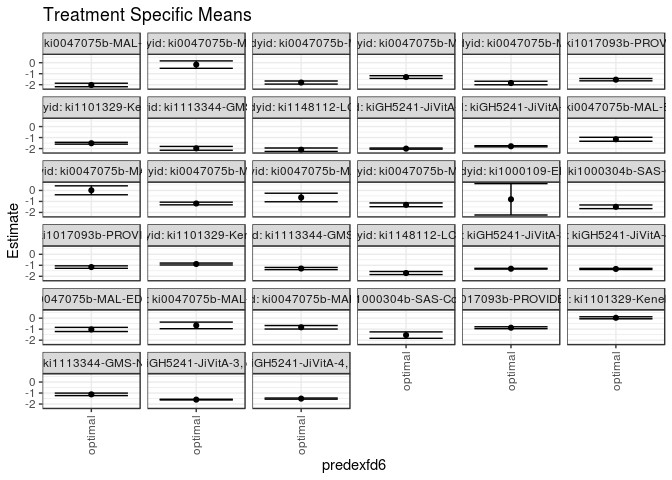

## Results Table

### Parameter: TSM

| agecat | studyid | country | intervention_level | baseline_level | estimate | ci_lower | ci_upper |
| --- | --- | --- | --- | --- | --- | --- | --- |
| Birth | ki0047075b-MAL-ED | BANGLADESH | optimal | observed | -1.0265774 | -1.2157047 | -0.8374501 |
| Birth | ki0047075b-MAL-ED | BRAZIL | optimal | observed | -0.6588000 | -0.9595518 | -0.3580482 |
| Birth | ki0047075b-MAL-ED | PERU | optimal | observed | -0.8310569 | -0.9909907 | -0.6711232 |
| Birth | ki1000304b-SAS-CompFeed | INDIA | optimal | observed | -1.5394402 | -1.8299178 | -1.2489627 |
| Birth | ki1017093b-PROVIDE | BANGLADESH | optimal | observed | -0.8687357 | -0.9548076 | -0.7826638 |
| Birth | ki1101329-Keneba | GAMBIA | optimal | observed | 0.0332351 | -0.0584172 | 0.1248874 |
| Birth | ki1113344-GMS-Nepal | NEPAL | optimal | observed | -1.1217596 | -1.2346611 | -1.0088580 |
| Birth | kiGH5241-JiVitA-3 | BANGLADESH | optimal | observed | -1.6010995 | -1.6341366 | -1.5680624 |
| Birth | kiGH5241-JiVitA-4 | BANGLADESH | optimal | observed | -1.5086007 | -1.5614412 | -1.4557601 |
| 6 months | ki0047075b-MAL-ED | BANGLADESH | optimal | observed | -1.1549793 | -1.3356672 | -0.9742915 |
| 6 months | ki0047075b-MAL-ED | BRAZIL | optimal | observed | 0.0116110 | -0.3952013 | 0.4184234 |
| 6 months | ki0047075b-MAL-ED | INDIA | optimal | observed | -1.1876229 | -1.3084343 | -1.0668114 |
| 6 months | ki0047075b-MAL-ED | NEPAL | optimal | observed | -0.6439581 | -1.0313496 | -0.2565667 |
| 6 months | ki0047075b-MAL-ED | PERU | optimal | observed | -1.3071274 | -1.4785075 | -1.1357472 |
| 6 months | ki1000109-EE | PAKISTAN | optimal | observed | -0.8066467 | -2.2335630 | 0.6202696 |
| 6 months | ki1000304b-SAS-CompFeed | INDIA | optimal | observed | -1.4877061 | -1.6531098 | -1.3223023 |
| 6 months | ki1017093b-PROVIDE | BANGLADESH | optimal | observed | -1.1619519 | -1.2748754 | -1.0490283 |
| 6 months | ki1101329-Keneba | GAMBIA | optimal | observed | -0.8831550 | -0.9686925 | -0.7976175 |
| 6 months | ki1113344-GMS-Nepal | NEPAL | optimal | observed | -1.2943362 | -1.3936711 | -1.1950014 |
| 6 months | ki1148112-LCNI-5 | MALAWI | optimal | observed | -1.7045276 | -1.8435858 | -1.5654694 |
| 6 months | kiGH5241-JiVitA-3 | BANGLADESH | optimal | observed | -1.3118960 | -1.3467111 | -1.2770808 |
| 6 months | kiGH5241-JiVitA-4 | BANGLADESH | optimal | observed | -1.3315006 | -1.3807523 | -1.2822489 |
| 24 months | ki0047075b-MAL-ED | BANGLADESH | optimal | observed | -2.0253516 | -2.1834909 | -1.8672123 |
| 24 months | ki0047075b-MAL-ED | BRAZIL | optimal | observed | -0.1723384 | -0.5071028 | 0.1624260 |
| 24 months | ki0047075b-MAL-ED | INDIA | optimal | observed | -1.8032116 | -1.9447792 | -1.6616440 |
| 24 months | ki0047075b-MAL-ED | NEPAL | optimal | observed | -1.3047416 | -1.4302574 | -1.1792258 |
| 24 months | ki0047075b-MAL-ED | PERU | optimal | observed | -1.8441388 | -2.0042978 | -1.6839798 |
| 24 months | ki1017093b-PROVIDE | BANGLADESH | optimal | observed | -1.5409667 | -1.6473134 | -1.4346201 |
| 24 months | ki1101329-Keneba | GAMBIA | optimal | observed | -1.5138450 | -1.5964412 | -1.4312489 |
| 24 months | ki1113344-GMS-Nepal | NEPAL | optimal | observed | -1.9774384 | -2.1505443 | -1.8043325 |
| 24 months | ki1148112-LCNI-5 | MALAWI | optimal | observed | -2.1046146 | -2.2606008 | -1.9486284 |
| 24 months | kiGH5241-JiVitA-3 | BANGLADESH | optimal | observed | -2.0045089 | -2.0552043 | -1.9538136 |
| 24 months | kiGH5241-JiVitA-4 | BANGLADESH | optimal | observed | -1.7905573 | -1.8409146 | -1.7402001 |

### Parameter: E(Y)

| agecat | studyid | country | intervention_level | baseline_level | estimate | ci_lower | ci_upper |
| --- | --- | --- | --- | --- | --- | --- | --- |
| Birth | ki0047075b-MAL-ED | BANGLADESH | observed | observed | -1.0530244 | -1.1913751 | -0.9146736 |
| Birth | ki0047075b-MAL-ED | BRAZIL | observed | observed | -0.6963333 | -0.9881882 | -0.4044785 |
| Birth | ki0047075b-MAL-ED | PERU | observed | observed | -0.9065728 | -1.0297267 | -0.7834188 |
| Birth | ki1000304b-SAS-CompFeed | INDIA | observed | observed | -1.3937088 | -1.5095039 | -1.2779137 |
| Birth | ki1017093b-PROVIDE | BANGLADESH | observed | observed | -0.8851020 | -0.9601332 | -0.8100709 |
| Birth | ki1101329-Keneba | GAMBIA | observed | observed | 0.0126443 | -0.0554367 | 0.0807254 |
| Birth | ki1113344-GMS-Nepal | NEPAL | observed | observed | -1.0641208 | -1.1525364 | -0.9757052 |
| Birth | kiGH5241-JiVitA-3 | BANGLADESH | observed | observed | -1.5955338 | -1.6186322 | -1.5724354 |
| Birth | kiGH5241-JiVitA-4 | BANGLADESH | observed | observed | -1.5273138 | -1.5765339 | -1.4780937 |
| 6 months | ki0047075b-MAL-ED | BANGLADESH | observed | observed | -1.1900794 | -1.3096296 | -1.0705291 |
| 6 months | ki0047075b-MAL-ED | BRAZIL | observed | observed | 0.0475758 | -0.0963508 | 0.1915023 |
| 6 months | ki0047075b-MAL-ED | INDIA | observed | observed | -1.2188303 | -1.3423090 | -1.0953516 |
| 6 months | ki0047075b-MAL-ED | NEPAL | observed | observed | -0.5622370 | -0.6774081 | -0.4470660 |
| 6 months | ki0047075b-MAL-ED | PERU | observed | observed | -1.3220326 | -1.4308168 | -1.2132484 |
| 6 months | ki1000109-EE | PAKISTAN | observed | observed | -2.1595486 | -2.5331781 | -1.7859192 |
| 6 months | ki1000304b-SAS-CompFeed | INDIA | observed | observed | -1.4697236 | -1.6333919 | -1.3060553 |
| 6 months | ki1017093b-PROVIDE | BANGLADESH | observed | observed | -1.0916915 | -1.1661176 | -1.0172654 |
| 6 months | ki1101329-Keneba | GAMBIA | observed | observed | -0.9331108 | -0.9823173 | -0.8839043 |
| 6 months | ki1113344-GMS-Nepal | NEPAL | observed | observed | -1.3540280 | -1.4334801 | -1.2745760 |
| 6 months | ki1148112-LCNI-5 | MALAWI | observed | observed | -1.6395956 | -1.7592633 | -1.5199278 |
| 6 months | kiGH5241-JiVitA-3 | BANGLADESH | observed | observed | -1.3138259 | -1.3418712 | -1.2857806 |
| 6 months | kiGH5241-JiVitA-4 | BANGLADESH | observed | observed | -1.3482303 | -1.3866421 | -1.3098185 |
| 24 months | ki0047075b-MAL-ED | BANGLADESH | observed | observed | -1.9576341 | -2.0857597 | -1.8295086 |
| 24 months | ki0047075b-MAL-ED | BRAZIL | observed | observed | 0.0061144 | -0.1625850 | 0.1748138 |
| 24 months | ki0047075b-MAL-ED | INDIA | observed | observed | -1.8863397 | -2.0168508 | -1.7558287 |
| 24 months | ki0047075b-MAL-ED | NEPAL | observed | observed | -1.3187671 | -1.4406685 | -1.1968657 |
| 24 months | ki0047075b-MAL-ED | PERU | observed | observed | -1.7524710 | -1.8736426 | -1.6312994 |
| 24 months | ki1017093b-PROVIDE | BANGLADESH | observed | observed | -1.6024221 | -1.6857420 | -1.5191023 |
| 24 months | ki1101329-Keneba | GAMBIA | observed | observed | -1.5876293 | -1.6406755 | -1.5345831 |
| 24 months | ki1113344-GMS-Nepal | NEPAL | observed | observed | -1.9002128 | -1.9869255 | -1.8135001 |
| 24 months | ki1148112-LCNI-5 | MALAWI | observed | observed | -1.9651323 | -2.1053230 | -1.8249415 |
| 24 months | kiGH5241-JiVitA-3 | BANGLADESH | observed | observed | -2.0118003 | -2.0479952 | -1.9756055 |
| 24 months | kiGH5241-JiVitA-4 | BANGLADESH | observed | observed | -1.7914765 | -1.8297816 | -1.7531715 |

### Parameter: PAR

| agecat | studyid | country | intervention_level | baseline_level | estimate | ci_lower | ci_upper |
| --- | --- | --- | --- | --- | --- | --- | --- |
| Birth | ki0047075b-MAL-ED | BANGLADESH | optimal | observed | -0.0264470 | -0.1845909 | 0.1316969 |
| Birth | ki0047075b-MAL-ED | BRAZIL | optimal | observed | -0.0375333 | -0.1535793 | 0.0785127 |
| Birth | ki0047075b-MAL-ED | PERU | optimal | observed | -0.0755159 | -0.1902982 | 0.0392665 |
| Birth | ki1000304b-SAS-CompFeed | INDIA | optimal | observed | 0.1457314 | -0.0954388 | 0.3869016 |
| Birth | ki1017093b-PROVIDE | BANGLADESH | optimal | observed | -0.0163663 | -0.0633465 | 0.0306139 |
| Birth | ki1101329-Keneba | GAMBIA | optimal | observed | -0.0205908 | -0.0848738 | 0.0436922 |
| Birth | ki1113344-GMS-Nepal | NEPAL | optimal | observed | 0.0576388 | -0.0309148 | 0.1461923 |
| Birth | kiGH5241-JiVitA-3 | BANGLADESH | optimal | observed | 0.0055657 | -0.0177941 | 0.0289255 |
| Birth | kiGH5241-JiVitA-4 | BANGLADESH | optimal | observed | -0.0187132 | -0.0474563 | 0.0100299 |
| 6 months | ki0047075b-MAL-ED | BANGLADESH | optimal | observed | -0.0351000 | -0.1801456 | 0.1099455 |
| 6 months | ki0047075b-MAL-ED | BRAZIL | optimal | observed | 0.0359647 | -0.3321430 | 0.4040725 |
| 6 months | ki0047075b-MAL-ED | INDIA | optimal | observed | -0.0312074 | -0.0784638 | 0.0160490 |
| 6 months | ki0047075b-MAL-ED | NEPAL | optimal | observed | 0.0817211 | -0.2786740 | 0.4421161 |
| 6 months | ki0047075b-MAL-ED | PERU | optimal | observed | -0.0149052 | -0.1619973 | 0.1321868 |
| 6 months | ki1000109-EE | PAKISTAN | optimal | observed | -1.3529019 | -2.7255004 | 0.0196966 |
| 6 months | ki1000304b-SAS-CompFeed | INDIA | optimal | observed | 0.0179824 | -0.0394213 | 0.0753861 |
| 6 months | ki1017093b-PROVIDE | BANGLADESH | optimal | observed | 0.0702604 | -0.0268790 | 0.1673997 |
| 6 months | ki1101329-Keneba | GAMBIA | optimal | observed | -0.0499558 | -0.1211417 | 0.0212300 |
| 6 months | ki1113344-GMS-Nepal | NEPAL | optimal | observed | -0.0596918 | -0.1187633 | -0.0006202 |
| 6 months | ki1148112-LCNI-5 | MALAWI | optimal | observed | 0.0649320 | -0.0106947 | 0.1405587 |
| 6 months | kiGH5241-JiVitA-3 | BANGLADESH | optimal | observed | -0.0019299 | -0.0212248 | 0.0173650 |
| 6 months | kiGH5241-JiVitA-4 | BANGLADESH | optimal | observed | -0.0167297 | -0.0504091 | 0.0169496 |
| 24 months | ki0047075b-MAL-ED | BANGLADESH | optimal | observed | 0.0677175 | -0.0513469 | 0.1867818 |
| 24 months | ki0047075b-MAL-ED | BRAZIL | optimal | observed | 0.1784528 | -0.1013270 | 0.4582326 |
| 24 months | ki0047075b-MAL-ED | INDIA | optimal | observed | -0.0831281 | -0.1428202 | -0.0234360 |
| 24 months | ki0047075b-MAL-ED | NEPAL | optimal | observed | -0.0140255 | -0.0432814 | 0.0152303 |
| 24 months | ki0047075b-MAL-ED | PERU | optimal | observed | 0.0916678 | -0.0174279 | 0.2007635 |
| 24 months | ki1017093b-PROVIDE | BANGLADESH | optimal | observed | -0.0614554 | -0.1287647 | 0.0058538 |
| 24 months | ki1101329-Keneba | GAMBIA | optimal | observed | -0.0737843 | -0.1409710 | -0.0065975 |
| 24 months | ki1113344-GMS-Nepal | NEPAL | optimal | observed | 0.0772256 | -0.0625881 | 0.2170393 |
| 24 months | ki1148112-LCNI-5 | MALAWI | optimal | observed | 0.1394823 | 0.0477615 | 0.2312031 |
| 24 months | kiGH5241-JiVitA-3 | BANGLADESH | optimal | observed | -0.0072914 | -0.0389971 | 0.0244143 |
| 24 months | kiGH5241-JiVitA-4 | BANGLADESH | optimal | observed | -0.0009192 | -0.0324122 | 0.0305738 |